# L1: Introduction to R Programming with a Case Study of MSFT and AAPL

## Connect to WRDS

```r
### WRDS Connection ###
library(RPostgres)
wrds = dbConnect(Postgres(),
                  host='wrds-pgdata.wharton.upenn.edu',
                  port=9737,
                  user='your username',
                  password='your password',
                  dbname='wrds',
                  sslmode='require')
```

## Example: Get Close Level of Dow Jones Index

There are huge amount of data within the WRDS database. The WRDS data are stored in SQL database format.

SQL (Structured Query Language) is a programming language used in programming and designed for managing data held in a relational database management system. It is particularly useful in handling structured data where there are relations between different entities/variables of the data.

```r
res = dbSendQuery(wrds, "select date,dji from djones.djdaily")
dj = dbFetch(res, n=-1)
dbClearResult(res)
print(head(dj))
```

```
##         date   dji
## 1 1896-05-26 40.94
## 2 1896-05-27 40.58
## 3 1896-05-28 40.20
## 4 1896-05-29 40.63
## 5 1896-06-01 40.60
## 6 1896-06-02 40.04
```

- Within this example: “select date,dji from djones.djdaily” is called a SQL quote. R is able to process different languages including SQL language. R send this quote to WRDS to get the date, and dji which are usually called fieldfrom the datatable called djones.djdaily.
- The returned results are stored in dj. The data type of dj is a R dataframe.
- R has many different datatype and dataframe is one of them. It is similar to an excel spreadsheet.
- The print() is a R function, allowing us to take a look of the data we put inside of the brackets().
- The R function head() allows us to view the top couple of lines in a dataframe.
- You could use ?head/?print to check the help document of the corresponding function in R.

## Get one single stock’s High Low Open Close Price: AAPL

- CRSP database in WRDS: The CRSP U.S. Stock database contains end-of-day and month-end prices on primary listings for the NYSE, NYSE MKT, NASDAQ, and Arca exchanges, along with basic market indices.
- Coverage of CRSP: All securities listed in CRSP U.S. Stock databases are equity securities, not bonds.
- CRSP U.S. Stock database contains the following information:
  - Price and quote data (e.g. Open, close, bid/low, ask/high, trade-only).
  - Holding period returns with and without dividends.
  - Excess returns and other derived data items.
  - Market capitalization.
  - Shares outstanding.
  - Trading volume.
  - Security delisting information.
  - Corporate actions.
  - Identifiers, descriptors, and supplemental data items.
- From ticker to the unique identifier(permno) in CRSP CRSP has a table called CRSP.DSENAMES, linking common stock identifiers: such as cusip, ticker, sedol, name to a unique id CRSP use to identify stocks.

PERMNO represents permanent number. Stocks can reuse cusip, ticker, sedol when they are merged/delisted/change name.

```r
q="select distinct ticker,permno from CRSP.DSENAMES where ticker='AAPL'"
res = dbSendQuery(wrds, q)
aapl.id = dbFetch(res, n=-1)
dbClearResult(res)
print(aapl.id)
```

```
##   ticker permno
## 1   AAPL  14593
```

```r
q=paste0("select permno,date,bidlo,askhi,openprc,prc,vol from CRSP.DSF where permno=", aapl.id$permno, "and date>='2015-01-01'")
print(q)
```

```
## [1] "select permno,date,bidlo,askhi,openprc,prc,vol from CRSP.DSF where permno=14593and date>='2015-01-01'"
```

```r
res = dbSendQuery(wrds, q)
aapl = dbFetch(res, n=-1)
dbClearResult(res)
print(head(aapl))
```

```
##   permno       date   bidlo  askhi openprc    prc      vol
## 1  14593 2015-01-02 107.350 111.44  111.39 109.33 53204828
## 2  14593 2015-01-05 105.410 108.65  108.29 106.25 64289001
## 3  14593 2015-01-06 104.630 107.43  106.54 106.26 65797116
## 4  14593 2015-01-07 106.695 108.20  107.20 107.75 40106644
## 5  14593 2015-01-08 108.700 112.15  109.23 111.89 59364547
## 6  14593 2015-01-09 110.210 113.25  112.67 112.01 53699527
```

- The paste0() function allows us to concatenate strings (in R, this is called character datatype) into longer strings.
- The $ sign allows us to select a column from a dataframe using its name: dataframe$columnname

# A Case Study of Long-Short Trading Using MSFT and AAPL

- An investor believe MSFT is a better stock than AAPL
  - She could either long MSFT, or short AAPL or do both at the same time.
- The benefit of long-short strategy is that she could achieve market neutral returns.
  - Market Neutral: A market-neutral strategy is a type of investment strategy undertaken by an investor or an investment manager that seeks to profit from both increasing and decreasing prices in one or more markets, while attempting to completely avoid some specific form of market risk.
  - AAPL and MSFT are both highly correlated with the entire market.
  - When market is bearish, MSFT as a better stock, drop less in value compared to AAPL, making the investor a profit.
  - When market is bullish, MSFT as a better stock, gets higher returns compared to AAPL, making the investor a profit.
- Step 1: get prices of AAPL and MSFT
- Step 2: check data quality
- Step 3: calculate returns of two stocks
- Step 4: calculate the relative performance of two stocks

## Get High Low Open Close Price of MSFT and AAPL

```r
q="select distinct ticker, permno from CRSP.DSENAMES where ticker in ('MSFT','AAPL')"
res = dbSendQuery(wrds, q)
stock.id = dbFetch(res, n=-1)
dbClearResult(res)
print(stock.id)
```

```
##   ticker permno
## 1   AAPL  14593
## 2   MSFT  10107
```

```r
q=paste0("select permno,date,bidlo,askhi,openprc,prc,vol from CRSP.DSF where permno in (",paste0(stock.id$permno,collapse = ','),") and date>='2015-01-01'")
print(q)
```

```
## [1] "select permno,date,bidlo,askhi,openprc,prc,vol from CRSP.DSF where permno in (14593,10107) and date>='2015-01-01'"
```

```r
res = dbSendQuery(wrds, q)
mystock = dbFetch(res, n=-1)
dbClearResult(res)
print(head(mystock))
```

```
##   permno       date bidlo   askhi openprc    prc      vol
## 1  10107 2015-01-02 46.54 47.4200   46.66 46.760 27913852
## 2  10107 2015-01-05 46.25 46.7300   46.37 46.325 39673865
## 3  10107 2015-01-06 45.54 46.7490   46.38 45.650 36447854
## 4  10107 2015-01-07 45.49 46.4600   45.98 46.230 29222067
## 5  10107 2015-01-08 46.72 47.7499   46.75 47.590 29645202
## 6  10107 2015-01-09 46.90 47.8200   47.61 47.190 23944181
```

- We can arrange the stock dataframe by date using the function arrange() from dplyr library
- Library or Packages are collections of R functions, data, and compiled code in a well-defined format.
- To install packages: install.packages(“dplyr”)
- To use a package already installed: library(dplyr)
- To use a function from a specific library, you should use library::function() , e.g. dplyr::arrange()

```r
library(dplyr)
mystock = mystock %>% arrange(date,permno)
print(head(mystock))
```

```
##   permno       date  bidlo   askhi openprc     prc      vol
## 1  10107 2015-01-02  46.54  47.420   46.66  46.760 27913852
## 2  14593 2015-01-02 107.35 111.440  111.39 109.330 53204828
## 3  10107 2015-01-05  46.25  46.730   46.37  46.325 39673865
## 4  14593 2015-01-05 105.41 108.650  108.29 106.250 64289001
## 5  10107 2015-01-06  45.54  46.749   46.38  45.650 36447854
## 6  14593 2015-01-06 104.63 107.430  106.54 106.260 65797116
```

- Different libraries could use the same name of functions.
- dplyr library is a very powerful library in R. It use %>% to concatenate multiple operations.
- arrange() is a function of dplyr, allowing us to sort data

## Checking the Data

- Since we are using real-world data, we have to perform at least some basic tests to make sure we have correct and complete data.
- We do not need to do all these tests for every single data series.
- Even though we have been using a data source regularly, it is still good practice to perform some basic tests on the data to ensure its continued reliability or to identify potential peculiarities with specific data series that we may not have been aware of.
- Plotting the data; Checking the Dimension; Outputting Summary Statistics

## Plot the MSFT Close Price and AAPL Close Price

We can filter MSFT stock from mystock data using dplyr function filter()

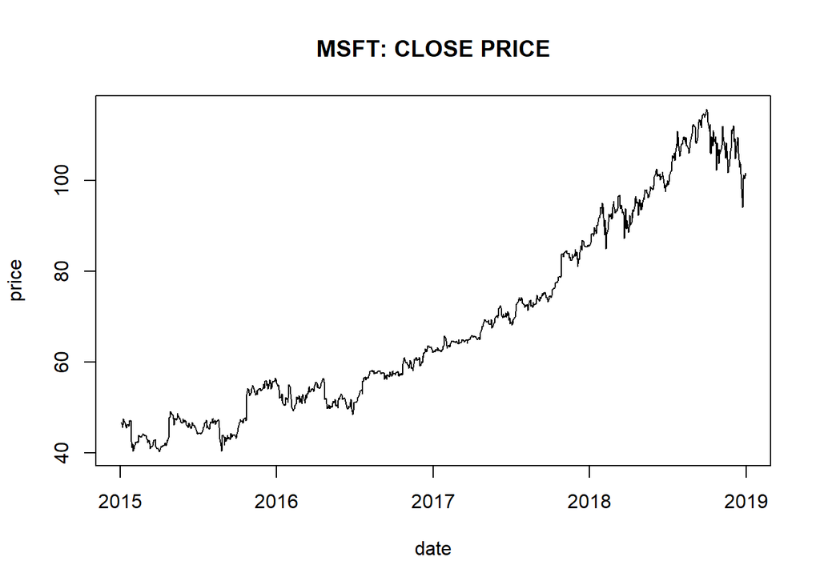

```r
msft = mystock %>% filter(permno=="10107")
aapl = mystock %>% filter(permno=="14593")
plot(msft$prc~as.Date(msft$date),type='l',ylab='price',xlab='date',
main='MSFT: CLOSE PRICE')
```

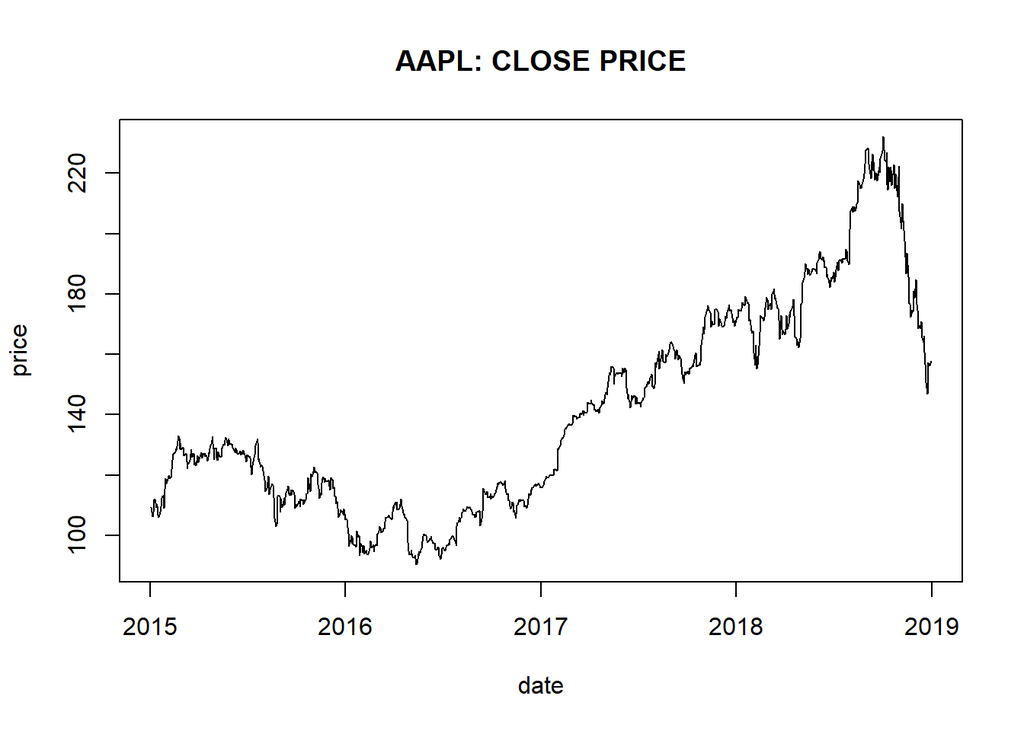

```r
plot(aapl$prc~aapl$date,type='l',ylab='price',xlab='date',
main='AAPL: CLOSE PRICE')
```

## Check the Dimension of Data

```r
dim(msft)
```

```
## [1] 1006    7
```

```r
dim(aapl)
```

```
## [1] 1006    7
```

```r
all(dim(msft)==dim(aapl))
```

```
## [1] TRUE
```

## Outputting Summary Statistics

- Another useful check is to look at the summary statistics of the data.
- summary() function from base R can output for each variable in the data object that variable’s minimum and maximum values, the interquartile range (25th percentile and 75th percentile), mean, and median.
- These metrics give a sense of whether there is anything out of the ordinary with the data. eg. a negative price or volume or an absurdly high price or volume may be a sign that there is something odd with the data and that we should investigate further.

```r
print(summary(aapl))
```

```
##      permno           date                bidlo            askhi
##  Min.   :14593   Min.   :2015-01-02   Min.   : 89.47   Min.   : 91.67
##  1st Qu.:14593   1st Qu.:2016-01-01   1st Qu.:110.62   1st Qu.:112.86
##  Median :14593   Median :2016-12-29   Median :128.31   Median :130.53
##  Mean   :14593   Mean   :2016-12-30   Mean   :139.75   Mean   :142.21
##  3rd Qu.:14593   3rd Qu.:2017-12-28   3rd Qu.:166.86   3rd Qu.:170.41
##  Max.   :14593   Max.   :2018-12-31   Max.   :229.78   Max.   :233.47
##     openprc           prc              vol
##  Min.   : 90.0   Min.   : 90.34   Min.   : 11475948
##  1st Qu.:112.0   1st Qu.:112.12   1st Qu.: 25164368
##  Median :129.2   Median :129.36   Median : 33340182
##  Mean   :141.0   Mean   :141.00   Mean   : 37915162
##  3rd Qu.:169.0   3rd Qu.:168.60   3rd Qu.: 45902420
##  Max.   :230.8   Max.   :232.07   Max.   :162268647
```

```r
print(summary(msft))
```

```
##      permno           date                bidlo            askhi
##  Min.   :10107   Min.   :2015-01-02   Min.   : 39.72   Min.   : 40.74
##  1st Qu.:10107   1st Qu.:2016-01-01   1st Qu.: 50.81   1st Qu.: 51.91
##  Median :10107   Median :2016-12-29   Median : 62.29   Median : 63.10
##  Mean   :10107   Mean   :2016-12-30   Mean   : 68.08   Mean   : 69.29
##  3rd Qu.:10107   3rd Qu.:2017-12-28   3rd Qu.: 85.37   3rd Qu.: 86.47
##  Max.   :10107   Max.   :2018-12-31   Max.   :114.93   Max.   :116.18
##     openprc            prc              vol
##  Min.   : 40.34   Min.   : 40.29   Min.   :        1
##  1st Qu.: 51.37   1st Qu.: 51.31   1st Qu.: 21182080
##  Median : 62.70   Median : 62.66   Median : 26725440
##  Mean   : 68.71   Mean   : 68.71   Mean   : 30248916
##  3rd Qu.: 86.18   3rd Qu.: 85.92   3rd Qu.: 34612307
##  Max.   :115.42   Max.   :115.61   Max.   :169170004
```

- The minimum trading volume of msft is 1, indicating an error.

## Looking into the error: basic data manipulation

- Subsetting data in R requires the addition of square brackets after the data object name (i.e., msft[,]).
- The terms inside the square bracket are separated by a comma.
- To the left of the comma are arguments we use to control the rows of the data and to the right of the comma are argument we use to control the columns of the data.
- To keep or delete one row, we place the row number to the left of the comma inside the square brackets. A negative sign in front of the row number will tell R to delete that row.
- For example, if we want to keep only the first row, we type [1,]. If we want to delete the first row, we type [−1,].
- We would like to find which date of MSFT has the trading volume=1 and delete the observation.

```r
print(head(msft))
```

```
##   permno       date bidlo   askhi openprc    prc      vol
## 1  10107 2015-01-02 46.54 47.4200   46.66 46.760 27913852
## 2  10107 2015-01-05 46.25 46.7300   46.37 46.325 39673865
## 3  10107 2015-01-06 45.54 46.7490   46.38 45.650 36447854
## 4  10107 2015-01-07 45.49 46.4600   45.98 46.230 29222067
## 5  10107 2015-01-08 46.72 47.7499   46.75 47.590 29645202
## 6  10107 2015-01-09 46.90 47.8200   47.61 47.190 23944181
```

```r
print(head(msft[-1,]))
```

```
##   permno       date bidlo   askhi openprc    prc      vol
## 2  10107 2015-01-05 46.25 46.7300   46.37 46.325 39673865
## 3  10107 2015-01-06 45.54 46.7490   46.38 45.650 36447854
## 4  10107 2015-01-07 45.49 46.4600   45.98 46.230 29222067
## 5  10107 2015-01-08 46.72 47.7499   46.75 47.590 29645202
## 6  10107 2015-01-09 46.90 47.8200   47.61 47.190 23944181
## 7  10107 2015-01-12 46.36 47.5400   47.42 46.600 23651887
```

```r
which(msft$vol==1)
```

```
## [1] 656
```

```r
summary(msft[-which(msft$vol==1),])
```

```
##      permno           date                bidlo            askhi
##  Min.   :10107   Min.   :2015-01-02   Min.   : 39.72   Min.   : 40.74
##  1st Qu.:10107   1st Qu.:2015-12-31   1st Qu.: 50.77   1st Qu.: 51.90
##  Median :10107   Median :2016-12-29   Median : 62.28   Median : 63.08
##  Mean   :10107   Mean   :2016-12-30   Mean   : 68.07   Mean   : 69.29
##  3rd Qu.:10107   3rd Qu.:2017-12-29   3rd Qu.: 85.40   3rd Qu.: 86.51
##  Max.   :10107   Max.   :2018-12-31   Max.   :114.93   Max.   :116.18
##     openprc            prc              vol
##  Min.   : 40.34   Min.   : 40.29   Min.   :  7425638
##  1st Qu.: 51.35   1st Qu.: 51.30   1st Qu.: 21188750
##  Median : 62.70   Median : 62.64   Median : 26734752
##  Mean   : 68.70   Mean   : 68.71   Mean   : 30279014
##  3rd Qu.: 86.20   3rd Qu.: 85.95   3rd Qu.: 34616550
##  Max.   :115.42   Max.   :115.61   Max.   :169170004
```

```r
msft = msft[-which(msft$vol==1),]
```

## Calculate Returns of Stocks

- Arithmetic return: $\dfrac{P_t}{P_{t-1}}-1$
- Logarithmic returns: $\log(P_t/P_{t-1})$
- Calculate msft arithmetic return using close price as an example

```r
msftret= msft %>% select(date,prc)
print(head(msftret))
```

```
##         date    prc
## 1 2015-01-02 46.760
## 2 2015-01-05 46.325
## 3 2015-01-06 45.650
## 4 2015-01-07 46.230
## 5 2015-01-08 47.590
## 6 2015-01-09 47.190
```

```r
msftret= msft %>% select(date,prc) %>%
  arrange(date) %>%
  mutate(lag.prc=lag(prc,1))
print(head(msftret))
```

```
##         date    prc lag.prc
## 1 2015-01-02 46.760      NA
## 2 2015-01-05 46.325  46.760
## 3 2015-01-06 45.650  46.325
## 4 2015-01-07 46.230  45.650
## 5 2015-01-08 47.590  46.230
## 6 2015-01-09 47.190  47.590
```

```r
msftret = msft %>% select(date,prc) %>%
  arrange(date) %>%
  mutate(lag.prc=lag(prc,1)) %>%
  mutate(msft.ret=prc/lag.prc-1) %>%
  select(date,msft.ret)

print(head(msftret))
```

```
##         date     msft.ret
## 1 2015-01-02           NA
## 2 2015-01-05 -0.009302771
## 3 2015-01-06 -0.014570949
## 4 2015-01-07  0.012705323
## 5 2015-01-08  0.029418140
## 6 2015-01-09 -0.008405159
```

```r
aaplret = aapl %>% select(date,prc) %>%
  arrange(date) %>%
  mutate(lag.prc=lag(prc,1)) %>%
  mutate(aapl.ret=prc/lag.prc-1) %>%
  select(date,aapl.ret)
print(head(aaplret))
```

```
##         date      aapl.ret
## 1 2015-01-02            NA
## 2 2015-01-05 -2.817161e-02
## 3 2015-01-06  9.413775e-05
## 4 2015-01-07  1.402219e-02
## 5 2015-01-08  3.842227e-02
## 6 2015-01-09  1.072506e-03
```

- select() function from dplyr allows us to select the columns in a dataframe we would like to keep or remove
- mutate() function from dplyr allows us to add a new column from some calculation
- lag(data,number of lag) function create lagged column of a column

## Relative Performance of AAPL and MSFT over the same period

- Merge msft and aapl return on date
- Check correlations of returns between msft and aapl
- Calculate the long msft, short aapl returns each day
- Calculate your cumulative returns of the long-short portfolio
- Visualisation

```r
# merge aapl and msft returns based on date
msft.aapl=aaplret %>% inner_join(msftret,by="date")
print(head(msft.aapl))
```

```
##         date      aapl.ret     msft.ret
## 1 2015-01-02            NA           NA
## 2 2015-01-05 -2.817161e-02 -0.009302771
## 3 2015-01-06  9.413775e-05 -0.014570949
## 4 2015-01-07  1.402219e-02  0.012705323
## 5 2015-01-08  3.842227e-02  0.029418140
## 6 2015-01-09  1.072506e-03 -0.008405159
```

```r
# correlation between two returns
print(cor(msft.aapl$aapl.ret,msft.aapl$msft.ret,use = "complete.obs"))
```

```
## [1] 0.5645453
```

```r
# relative performance of msft and aapl
msft.aapl = msft.aapl %>% mutate(msft.aapl.ret=msft.ret-aapl.ret)

# summarise your long-short returns

summary(msft.aapl$msft.aapl.ret)
```

```
##       Min.    1st Qu.     Median       Mean    3rd Qu.       Max.
## -0.0909914 -0.0062013  0.0004667  0.0004100  0.0073943  0.0998181
##       NA's
##          1
```

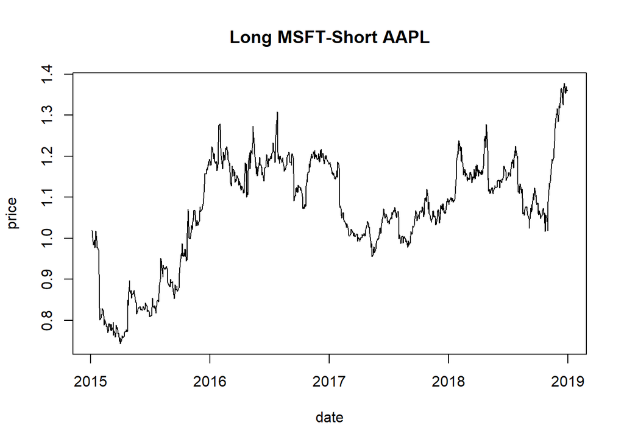

```r
# cumulative returns of long-short position
msft.aapl = msft.aapl %>% arrange(date) %>%
  filter(!is.na(msft.aapl.ret)) %>%
  mutate(cumret=cumprod(msft.aapl.ret+1))

# plot your cummulative return
plot(msft.aapl$cumret~as.Date(msft.aapl$date),
     type='l',ylab='price',xlab='date',
     main='Long MSFT-Short AAPL')
```

## Save and load your data

- Save to binary .RData using save(data,file=“location/filename.RData”)
- Save data to csv using write.csv(data,file=‘location/filename.csv’)
- Load .RData load(“location/filename.RData”)
- Load csv data read.csv(“location/filename.csv”)
- delete variable from enviornment using rm()

```r
save(msft.aapl,file='C:/Users/siche/Documents/teaching/Introduction to Financial Data Analysis/L1/msft.aapl.RData')
write.csv(msft,file='C:/Users/siche/Documents/teaching/Introduction to Financial Data Analysis/L1/msft.csv')
write.csv(aapl,file='C:/Users/siche/Documents/teaching/Introduction to Financial Data Analysis/L1/aapl.csv')
write.csv(dj,file='C:/Users/siche/Documents/teaching/Introduction to Financial Data Analysis/L1/dj.csv')
rm(msft,aapl,dj,msft.aapl)
load("C:/Users/siche/Documents/teaching/Introduction to Financial Data Analysis/L1/msft.aapl.RData")
aapl = read.csv("C:/Users/siche/Documents/teaching/Introduction to Financial Data Analysis/L1/aapl.csv")
print(head(aapl))
```

[output not shown]